# NoBrainHeterogeneity

Let’s plot singletons:

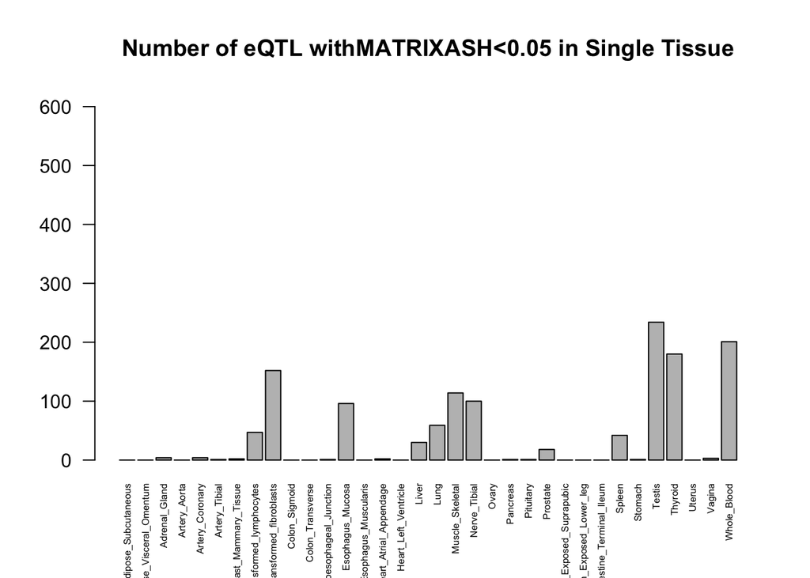

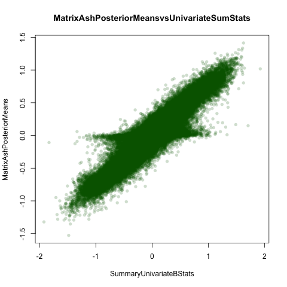

```
## [1] "/Users/sarahurbut/gtexresults_matrixash/Analysis"
```

We can consider the number of statistics at each threshold using both methods:

```r
thresh=0.05
sum(lfsr.mash<thresh)
```

```
## [1] 303809
```

Let’s also count how many associations we might count as inconsistent by simply counting the number of times the signs differed in a vector of posterior means for a given gene snp pair. This changes without brain, as with brain, there were 9597 inconsistent instances.

```r
inconsistent.func=function(posterior.means,lfsr,thresh=0.05){
h=apply(posterior.means,1,function(p){
  pos=sum(p>0);neg=sum(p<0);pos*neg!=0})
sum(h=="TRUE")}
inconsistent.func(pm.mash.beta,lfsr.mash)
```

```
## [1] 7723
```

```r
inconsistent.func(pm.ash.beta,lfsr.mash)
```

```
## [1] 14074
```

If we restrict our analysis to only those considered significant at an lfsr threshold using ash computed LFSR, we have a smaller number, but this is simply because so many fewer associations are called significant using ash. Using the MASH lfsrs, the results are identical to using the univariate z statistics. WE can compare to the matrix ash posterior means as well. This was 3180 (roughtly 20% of the genes) when using Brains.

```r
 thresh=0.05



z=sapply(seq(1:nrow(pm.mash.beta)),function(x){
l=lfsr.mash[x,];p=pm.mash.beta[x,];plow=p[which(l<thresh)];##grab only those posterior means that are 'significant'
if(length(plow)==0){return("FALSE")}##for ones who show no significants, they can't be heterogenous
else{pos=sum(plow>0);neg=sum(plow<0);pos*neg!=0}})
sum(z==TRUE)
```

```
## [1] 2377
```

We can also consider a histogram of normalized posterior means and compute how often there is consistency in sign.

```r
maxb=read.table("../Data/maxbetahats.txt")[,-c(7:16)]

bnorm=het.norm(effectsize = maxb)
sum(bnorm>0)/length(bnorm)
```

```
## [1] 0.726567
```

```r
matrix.ash.norm=het.norm(effectsize = pm.mash.beta)
sum(matrix.ash.norm>0)/length(matrix.ash.norm)
```

```
## [1] 0.8797172
```

```r
uni.ash.norm=het.norm(effectsize = pm.ash.beta)
sum(uni.ash.norm>0)/length(matrix.ash.norm)
```

```
## [1] 0.7299788
```

```r
pm.mash.beta.brain=read.table("../Data//Aug13withEDposterior.betas.txt")
matrix.ash.norm.brain=het.norm(effectsize = pm.mash.beta.brain)
sum(matrix.ash.norm.brain>0)/length(matrix.ash.norm.brain)
```

```
## [1] 0.8330297
```

```r
ash.norm=het.norm(effectsize = pm.ash.beta)
```

```r
sum(bnorm>0.5)/length(bnorm)
```

```
## [1] 0.2141482
```

```r
sum(uni.ash.norm>0.5)/length(bnorm)
```

```
## [1] 0.1382311
```

```r
sum(matrix.ash.norm>0.5)/length(matrix.ash.norm)
```

```
## [1] 0.4497242
```

```r
sum(matrix.ash.norm.brain>0.5)/length(matrix.ash.norm.brain)
```

```
## [1] 0.3540626
```

Now, let’s plot:

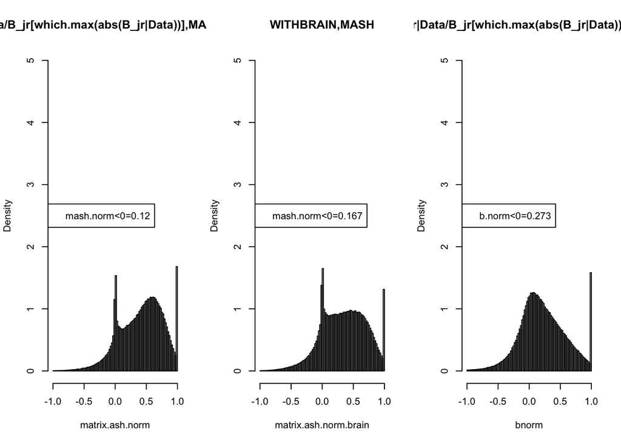

```r
par(mfrow=c(1,3))

hist(matrix.ash.norm,freq=FALSE,ylim=c(0,5),nclass=100,main="B_jr|Data/B_jr[which.max(abs(B_jr|Data))],MASHNOBRAIN")
legend("left",legend=paste0("mash.norm<0=",round((sum(matrix.ash.norm<0)/length(matrix.ash.norm)),3)))
hist(matrix.ash.norm.brain,freq=FALSE,ylim=c(0,5),nclass=100,main="WITHBRAIN,MASH")
legend("left",legend=paste0("mash.norm<0=",round((sum(matrix.ash.norm.brain<0)/length(matrix.ash.norm.brain)),3)))
hist(bnorm,freq=FALSE,ylim=c(0,5),nclass=100,main="B_jr|Data/B_jr[which.max(abs(B_jr|Data))],B_raw")
legend("left",legend=paste0("b.norm<0=",round((sum(bnorm<0)/length(matrix.ash.norm)),3)))
```

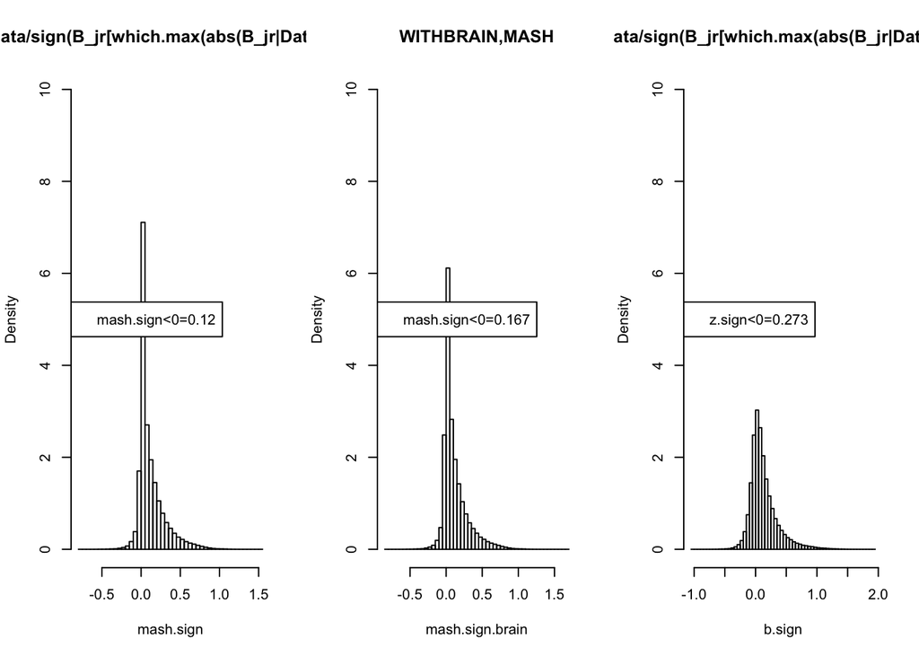

```r
mash.sign=sign.norm(effectsize = pm.mash.beta)
mash.sign.brain=sign.norm(effectsize = pm.mash.beta.brain)

b.sign=sign.norm(effectsize = maxb)

par(mfrow=c(1,3))
hist(mash.sign,freq=FALSE,ylim=c(0,10),main="B_jr|Data/sign(B_jr[which.max(abs(B_jr|Data))],MASH",nclass=50)
legend("left",legend=paste0("mash.sign<0=",round((sum(matrix.ash.norm<0)/length(matrix.ash.norm)),3)))
hist(mash.sign.brain,freq=FALSE,ylim=c(0,10),main="WITHBRAIN,MASH",nclass=50)
legend("left",legend=paste0("mash.sign<0=",round((sum(matrix.ash.norm.brain<0)/length(matrix.ash.norm.brain)),3)))
hist(b.sign,freq=FALSE,ylim=c(0,10),main="B_jr|Data/sign(B_jr[which.max(abs(B_jr|Data))],Z.raw)",nclass=50)
legend("left",legend=paste0("z.sign<0=",round((sum(bnorm<0)/length(bnorm)),3)))
```

Understandably, there are no examples in which the sign of the posterior mean using univariate ash is flipped because there is no sharing of information across tissues, while with matrix ash, the sign changes about 18% of the time:

```r
b.stat=maxb
sum2=b.stat*pm.mash.beta
sum(sum2<0)/length(unlist(sum2))
```

```
## [1] 0.1792216
```

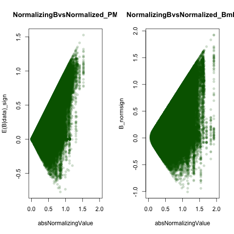

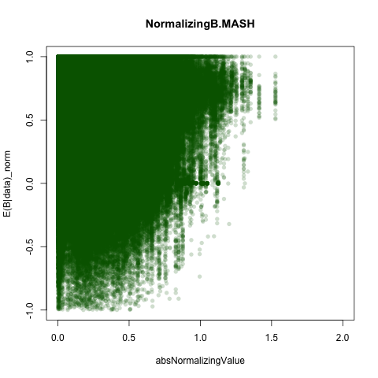

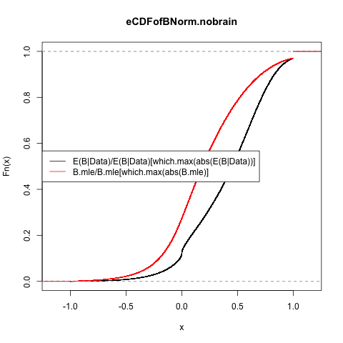

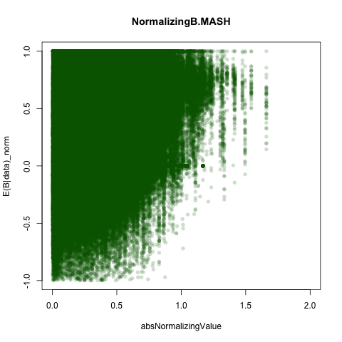

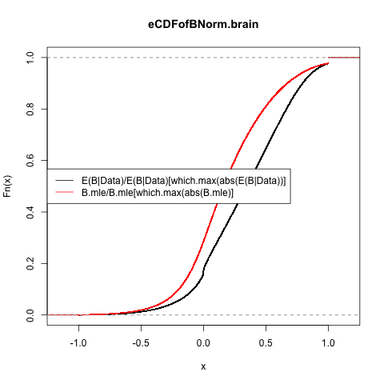

And finally, we can compare the magnitude heterogeneity - that is, the number of tissues in which the eQTL has an activity greater than $\alpha$ or (less than $\alpha$) of the maximum effect.

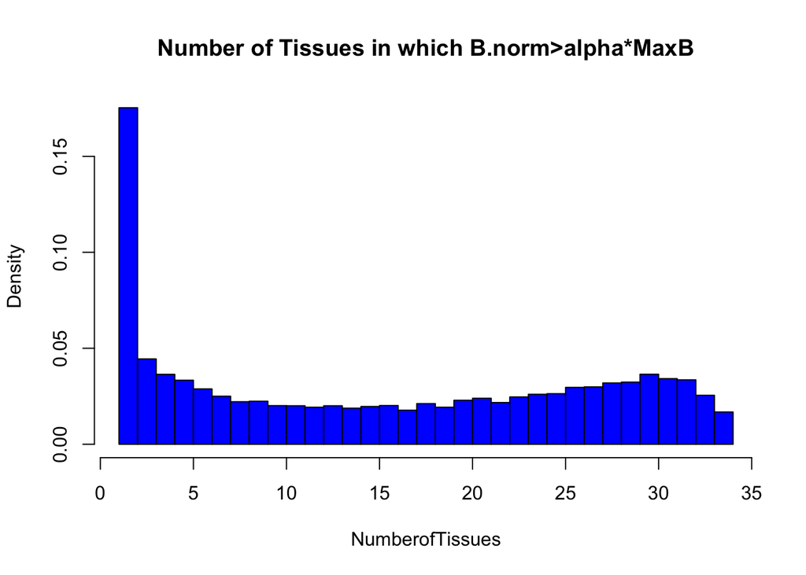

Let’s compare to using the brains:

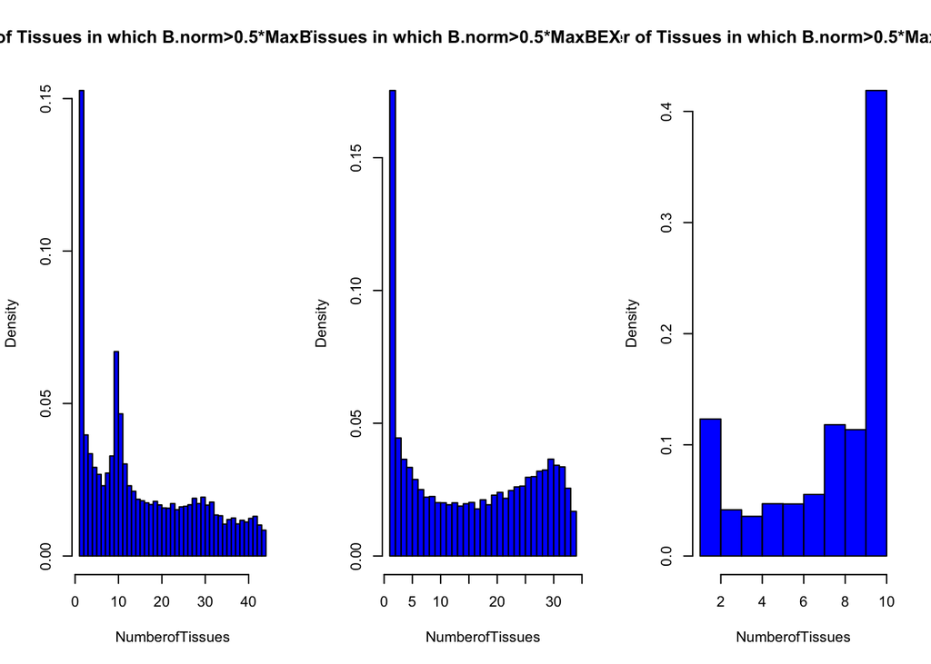

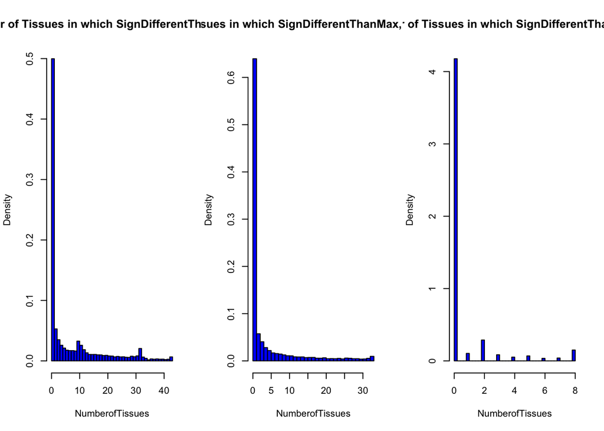

Now, let’s consider the number of tissues vs normalziing value. We plot the median of the value used to normalize for each group of SNPs that are of the same number of tissue class.

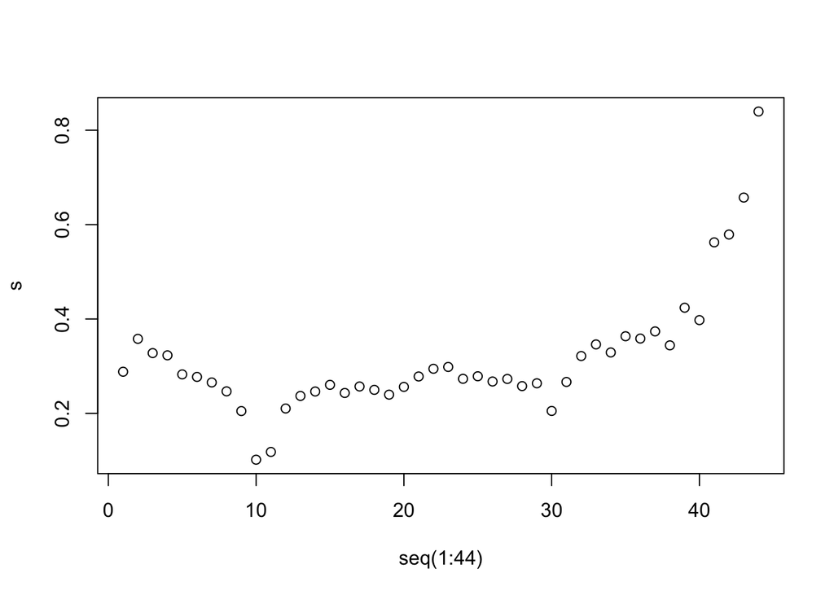

```r
ebnorm=het.norm(effectsize=pm.mash.beta.brain)
h=het.func(ebnorm,threshold=0.5)
max.mash.brain=apply(pm.mash.beta.brain,1,function(x){
(x[which.max(abs(x))])})
s=sapply(seq(1:44),function(x){
tissue.match=which(h==x)
median(abs(max.mash.brain[tissue.match]))})

plot(seq(1:44),s)
```

Now, let’s look at excluding brain:

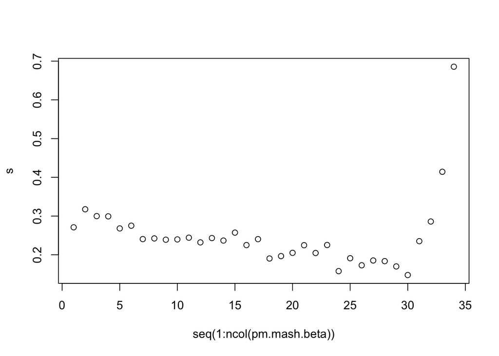

```r
ebnorm=het.norm(effectsize=pm.mash.beta)
h=het.func(ebnorm,threshold=0.5)
max.mash=apply(pm.mash.beta,1,function(x){
(x[which.max(abs(x))])})
s=sapply(seq(1:ncol(pm.mash.beta)),function(x){
tissue.match=which(h==x)
median(abs(max.mash[tissue.match]))})

plot(seq(1:ncol(pm.mash.beta)),s)
```

Let’s compare the empirical distribtuion with and wihtout brains of the proportion of tissues which are greater than 50% of maximum effect:

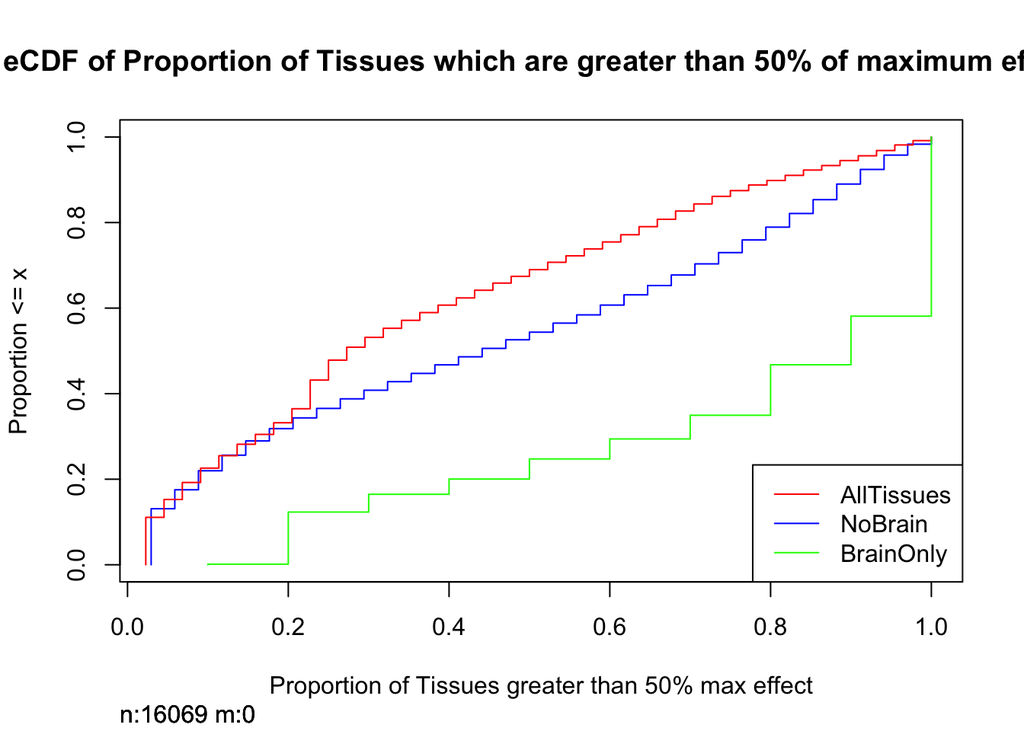

```r
require( Hmisc )
Ecdf(x = het.func(het.norm(effectsize=pm.mash.beta),threshold=0.5)/34,main="eCDF of Proportion of Tissues which are greater than 50% of maximum effect",col="blue",lty=1,xlab="Proportion of Tissues greater than 50% max effect")
Ecdf(x = het.func(het.norm(effectsize=pm.mash.beta.brain),threshold=0.5)/44,add = TRUE, col = 'red', lty = 1)
Ecdf(x = het.func(brain.norm,threshold=0.5)/10,add = TRUE, col = 'green', lty = 1)
legend("bottomright",legend=c("AllTissues","NoBrain","BrainOnly"),col=c("red","blue","green"),lty=c(1,1,1))
```

Let’s comapre the sum of normalized bstatistics across tissues.For each gene, compute sum (norm.b)^2 such that norm.b>0 (eliminate off diretion).

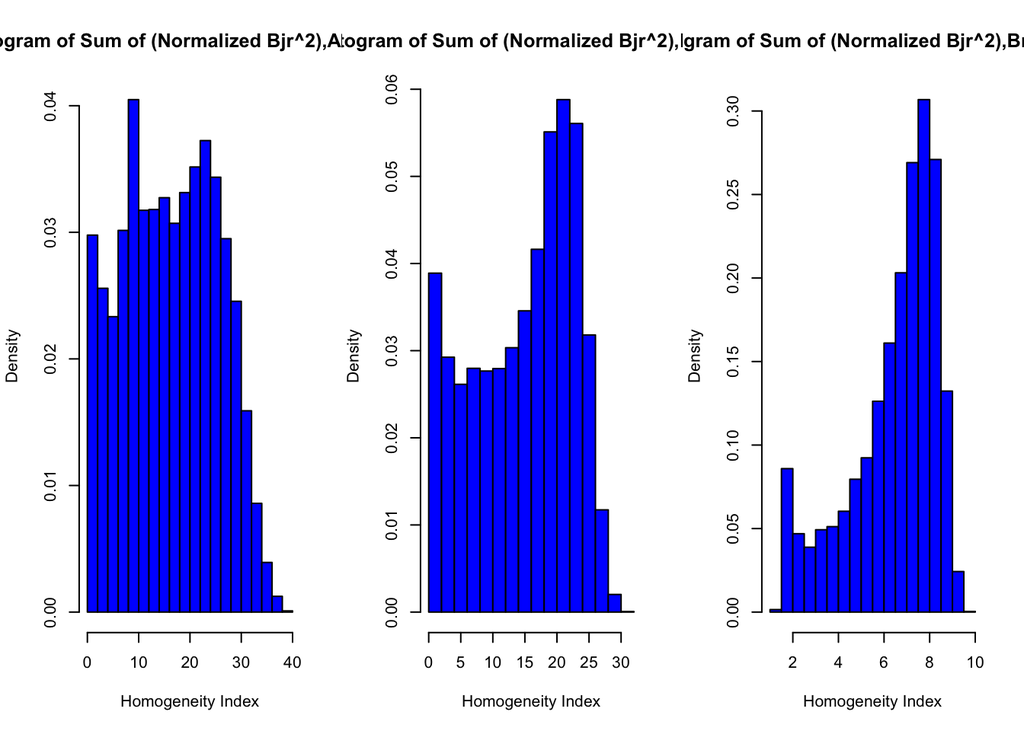